# UNIVERSIDAD DE LAS AMÉRICAS

**INTELIGENCIA ARTIFICIAL II**  
ISWZ – 3402  
**P1 Project: Implement a Recommender system using a bipartite network projection**

### Estudiantes

- Joaquín Chacón
- Gabriel Arguello
- Andres Jimenez
- Junior Espin
- Mathew Baquero

## Marco Teórico

### Resumen

Con este trabajo se implementa un **sistema de filtrado colaborativo basado en grafos** para el dataset de reseñas de electrónicos de Amazon. El núcleo del sistema es la proyección algebraica de una red bipartita usuario–producto sobre el espacio de productos, produciendo una red unipartita ponderada donde el peso de cada arista cuantifica la similitud entre pares de productos en función de la co-ocurrencia de evaluadores. Este enfoque constituye una instancia de *collaborative filtering item-based* sin descomposición matricial explícita, formulado directamente en el lenguaje de la teoría de redes.

### Redes Bipartitas y Proyección

#### Definición formal del grafo bipartito

Sea $G = (U \cup V, E)$ un grafo bipartito donde:

- $U = \{u_1, \ldots, u_m\}$ es el conjunto de **usuarios** ($m = 117$)
- $V = \{v_1, \ldots, v_n\}$ es el conjunto de **productos** ($n = 76$)
- $E \subseteq U \times V$, con $(u_i, v_j) \in E$ si y solo si el usuario $u_i$ calificó el producto $v_j$ con rating $\geq 5$

La condición de bipartición implica que todo camino entre nodos del mismo lado tiene longitud par, y no existen aristas entre dos usuarios ni entre dos productos.

#### Matriz Biadyacente

La representación algebraica es la **matriz biadyacente** $B \in \{0,1\}^{m \times n}$:

$$B_{ij} = \begin{cases} 1 & \text{si } (u_i, v_j) \in E \\ 0 & \text{en caso contrario} \end{cases}$$

La forma resultante es $B \in \{0,1\}^{117 \times 76}$ con 766 entradas no nulas, correspondiente a una densidad del $\approx 8.6\%$, lo que justifica el uso de representación dispersa en formato CSR (Saad, 2003).

#### Proyección producto–producto: $P = B^\top B$

La operación central del sistema es el producto matricial:

$$P = B^\top B \in \mathbb{Z}^{n \times n}$$

Cada entrada $P_{ij}$ tiene una interpretación combinatoria precisa:

$$P_{ij} = \sum_{k=1}^{m} B_{ki} \cdot B_{kj} = |N(v_i) \cap N(v_j)|$$

donde $N(v)$ denota el conjunto de vecinos (usuarios) del producto $v$ en el grafo bipartito. Es decir, $P_{ij}$ cuenta exactamente cuántos usuarios calificaron positivamente tanto el producto $i$ como el $j$. Esta es la proyección estándar descrita en Latapy, Magnien y Del Vecchio (2008).

La diagonal $P_{ii} = |N(v_i)| = \deg(v_i)$ contabiliza los usuarios del producto $i$ y se elimina para evitar autoconexiones.

#### Métrica de similitud y sesgo de popularidad

El sistema emplea la intersección cruda $P_{ij}$ como métrica de similitud. La literatura estándar (Koren, Bell & Volinsky, 2009) propone normalizaciones para corregir el sesgo de popularidad:

$$\text{Jaccard}(v_i, v_j) = \frac{|N(v_i) \cap N(v_j)|}{|N(v_i) \cup N(v_j)|} \qquad \text{Coseno}(v_i, v_j) = \frac{P_{ij}}{\sqrt{P_{ii} \cdot P_{jj}}}$$

donde $P_{ii}$ y $P_{jj}$ son los grados de los productos antes de eliminar la diagonal.

## Descripción del Proyecto

Este proyecto implementa un **sistema de recomendación basado en grafos** utilizando el dataset de reseñas de electrónicos de Amazon. La idea central es modelar las interacciones entre usuarios y productos como una **red bipartita**, y luego proyectarla sobre el conjunto de productos para obtener una red unipartita ponderada.

Dos productos quedan conectados si fueron calificados positivamente por los mismos usuarios; el peso de esa conexión indica cuántos usuarios los compartieron. A partir de esa red, el sistema recomienda los productos más similares a uno dado.

**Dataset:** [Amazon Product Reviews – Electronics](https://www.kaggle.com/datasets/saurav9786/amazon-product-reviews) (Kaggle)

## 1. Importaciones y Parámetros de Configuración

Como base, es necesario importar todas las librerías necesarias y definir las constantes globales que controlan el comportamiento del sistema: umbrales de filtrado, tamaños de figura y límites de la red.

Con esto, se obtiene un entorno de ejecución configurado. Las variables `HAS_WIDGETS` y `HAS_PLOTLY` indican si las dependencias opcionales de visualización interactiva están disponibles.

```python
import warnings
warnings.filterwarnings("ignore")

import os
import glob
import numpy as np
import pandas as pd
import networkx as nx
import matplotlib.pyplot as plt
import kagglehub

from scipy.sparse import csr_matrix
from IPython.display import display, clear_output

try:
    import ipywidgets as widgets
    HAS_WIDGETS = True
except Exception:
    HAS_WIDGETS = False

try:
    import plotly.graph_objects as go
    HAS_PLOTLY = True
except Exception:
    HAS_PLOTLY = False

# --- Filtrado del dataset ---
KEEP_ONLY_FIVE_STARS   = True   # Conservar solo ratings >= RATING_THRESHOLD
RATING_THRESHOLD       = 5.0
MIN_USER_REVIEWS       = 5      # Mínimo de reseñas por usuario (k-core)
MIN_PRODUCT_REVIEWS    = 5      # Mínimo de reseñas por producto (k-core)
MIN_SHARED_USERS       = 2      # Mínimo de usuarios compartidos para crear arista
TOP_PRODUCTS_FOR_DROPDOWN = 300 # Productos disponibles en el dropdown interactivo
DEFAULT_TOP_N          = 4      # Número de recomendaciones por defecto

# --- Tamaños de figuras ---
STAR_FIGSIZE    = (9, 7)
NETWORK_FIGSIZE = (12, 9)
HIST_FIGSIZE    = (7, 4)

# --- Tamaños de nodos en visualizaciones de recomendación ---
NODE_SIZE_MAIN     = 1400
NODE_SIZE_NEIGHBOR = 850

# --- Parámetros de recorte para la visualización de la red ---
TRIM_WEIGHT_MIN            = 3
TRIM_WEIGHT_MAX            = 15
TRIMMED_NETWORK_MAX_NODES  = 80
TRIMMED_NETWORK_MIN_DEGREE = 2
TRIMMED_NETWORK_LABEL_TOP_N = 18
```

## 2. Carga del Dataset

Primero, descargamos automáticamente el dataset de Amazon Electronics desde Kaggle y cargarlo en un DataFrame de Pandas obteniendo datos crudos listos para el preprocesamiento, con las columnas `userId`, `productId`, `Rating` y `timestamp`. La carga se limita a 1,048,576 filas para controlar el uso de memoria.

```python
path = kagglehub.dataset_download("saurav9786/amazon-product-reviews")
print("Path to dataset files:", path)

csv_files = glob.glob(os.path.join(path, "*.csv"))
print("CSV encontrados:", [os.path.basename(f) for f in csv_files])

target_file = None
for f in csv_files:
    if "ratings_Electronics" in os.path.basename(f):
        target_file = f
        break

if target_file is None:
    if len(csv_files) == 1:
        target_file = csv_files[0]
    else:
        raise FileNotFoundError("No se pudo identificar automaticamente el archivo ratings_Electronics.")

electronics_data = pd.read_csv(
    target_file,
    names=["userId", "productId", "Rating", "timestamp"]
)
electronics_data = electronics_data.iloc[:1048576, :].copy()

df = electronics_data.copy()

user_col    = "userId"
product_col = "productId"
rating_col  = "Rating"
time_col    = "timestamp"
```

```
Downloading to /root/.cache/kagglehub/datasets/saurav9786/amazon-product-reviews/1.archive...
```

```
Extracting files...
```

```
Path to dataset files: /root/.cache/kagglehub/datasets/saurav9786/amazon-product-reviews/versions/1
CSV encontrados: ['ratings_Electronics (1).csv']
```

## 3. Preprocesamiento

Se limpió el dataset eliminando valores nulos, conservar únicamente las calificaciones de 5 estrellas y aplicar un **filtro k-core iterativo** que retiene solo usuarios con al menos 5 reseñas y productos con al menos 5 calificaciones. Este proceso garantiza que la red tenga suficiente densidad para generar recomendaciones confiables.

El dataset filtrado resultante generó 766 filas, 117 usuarios únicos y 76 productos únicos. Se proyectan tres histogramas: distribución de ratings, grado de usuarios y grado de productos.

### Análisis: Umbral de Rating y Filtrado k-Core Bipartito

#### Umbral de rating (`RATING_THRESHOLD = 5.0`)

La decisión de retener exclusivamente calificaciones de 5 estrellas tiene implicaciones estadísticas directas:

- **Ventaja:** Elimina el ruido semántico asociado a ratings intermedios. Una calificación de 4 estrellas puede interpretarse de manera heterogénea entre usuarios (*sesgo de escala*), mientras que 5 estrellas denota preferencia positiva inequívoca en el contexto Amazon.
- **Desventaja:** Reduce drásticamente el volumen de datos disponibles. De las 1,048,576 filas cargadas, el filtro retiene únicamente el subconjunto con rating = 5, lo que introduce un *sesgo de positividad* que favorece productos populares y puede reducir la capacidad de distinción entre ellos.
- **Consecuencia estadística:** Todos los ratings retenidos son iguales a 5.0, por lo que la distribución de ratings tiene varianza cero. El histograma produce una única barra, resultado matemáticamente esperado y no un error del código.

#### Filtrado bipartito iterativo k-core

La función `iterative_k_core_filter` implementa una **descomposición de núcleo bipartito** con parámetros $(k_U, k_V) = (5, 5)$:

$$\textbf{Dado } G = (U \cup V, E): \quad \text{Repetir hasta convergencia:} \begin{cases} \text{Eliminar } u \in U \text{ con } \deg(u) < 5 \\ \text{Eliminar } v \in V \text{ con } \deg(v) < 5 \end{cases}$$

El $(k_U, k_V)$-core de un grafo bipartito es el subgrafo maximal donde todo nodo usuario tiene grado $\geq k_U$ y todo nodo producto tiene grado $\geq k_V$. Su existencia y unicidad están garantizadas (Batagelj & Zaversnik, 2003). La convergencia del algoritmo iterativo se garantiza porque en cada iteración el número de nodos es no-creciente y el grafo es finito.

**Efecto observado:** El dataset pasa de 1,048,576 filas a **766 filas** con 117 usuarios y 76 productos únicos — una contracción del $\approx 99.93\%$. Esta reducción evidencia que la combinación del filtro de rating máximo y el k-core es altamente restrictiva. En producción, relajar alguno de los dos umbrales (e.g., `RATING_THRESHOLD = 4.0` o `MIN_USER_REVIEWS = 3`) aumentaría la cobertura a costa de introducir señales de menor calidad.

```
RESUMEN DEL DATASET
------------------------------------------------------------
Numero de filas: 766
Usuarios unicos: 117
Productos unicos: 76
Promedio de rating: 5.0000
Mediana de rating: 5.0000
```

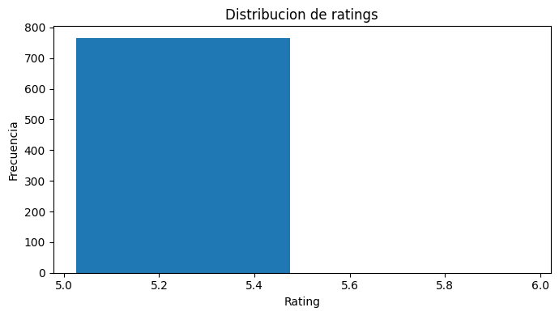

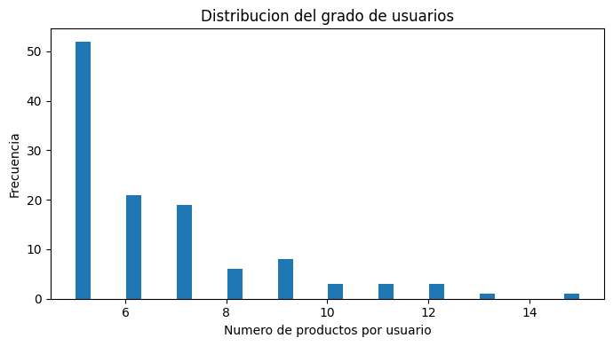

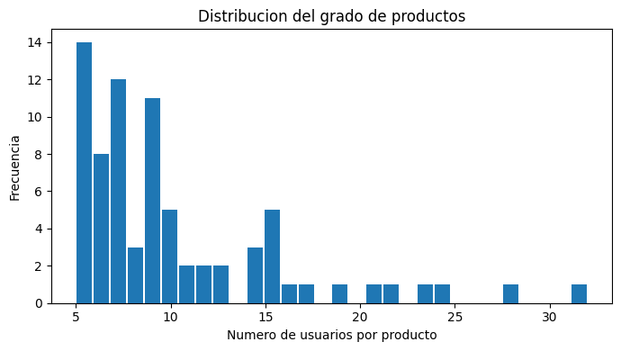

```python
def iterative_k_core_filter(df, user_col, product_col, min_user_reviews=5, min_product_reviews=5):
    """Filtra iterativamente usuarios y productos con actividad por debajo del umbral mínimo."""
    filtered = df.copy()
    changed = True

    while changed:
        changed = False

        user_counts = filtered[user_col].value_counts()
        valid_users = user_counts[user_counts >= min_user_reviews].index
        new_filtered = filtered[filtered[user_col].isin(valid_users)]
        if len(new_filtered) != len(filtered):
            filtered = new_filtered
            changed = True

        product_counts = filtered[product_col].value_counts()
        valid_products = product_counts[product_counts >= min_product_reviews].index
        new_filtered = filtered[filtered[product_col].isin(valid_products)]
        if len(new_filtered) != len(filtered):
            filtered = new_filtered
            changed = True

    return filtered


def summarize_dataset(df, user_col, product_col, rating_col):
    """Imprime un resumen estadístico básico del dataset."""
    print("RESUMEN DEL DATASET")
    print("-" * 60)
    print(f"Numero de filas: {len(df):,}")
    print(f"Usuarios unicos: {df[user_col].nunique():,}")
    print(f"Productos unicos: {df[product_col].nunique():,}")
    print(f"Promedio de rating: {df[rating_col].mean():.4f}")
    print(f"Mediana de rating: {df[rating_col].median():.4f}")
    print()


def plot_rating_distribution(df, rating_col):
    """Histograma de la distribución empírica de ratings."""
    plt.figure(figsize=HIST_FIGSIZE)
    vals = df[rating_col].dropna().astype(float)
    plt.hist(vals, bins=np.arange(vals.min(), vals.max() + 1.5, 0.5), rwidth=0.9)
    plt.xlabel("Rating")
    plt.ylabel("Frecuencia")
    plt.title("Distribucion de ratings")
    plt.tight_layout()
    plt.show()


def plot_degree_histograms(df, user_col, product_col):
    """Histogramas del número de interacciones por usuario y por producto."""
    user_deg = df[user_col].value_counts().values
    prod_deg = df[product_col].value_counts().values

    plt.figure(figsize=HIST_FIGSIZE)
    plt.hist(user_deg, bins=30, rwidth=0.9)
    plt.xlabel("Numero de productos por usuario")
    plt.ylabel("Frecuencia")
    plt.title("Distribucion del grado de usuarios")
    plt.tight_layout()
    plt.show()

    plt.figure(figsize=HIST_FIGSIZE)
    plt.hist(prod_deg, bins=30, rwidth=0.9)
    plt.xlabel("Numero de usuarios por producto")
    plt.ylabel("Frecuencia")
    plt.title("Distribucion del grado de productos")
    plt.tight_layout()
    plt.show()


# --- Limpieza y filtrado ---
df = df.dropna(subset=[user_col, product_col, rating_col]).copy()
df[user_col]    = df[user_col].astype(str)
df[product_col] = df[product_col].astype(str)
df[rating_col]  = pd.to_numeric(df[rating_col], errors="coerce")
df = df.dropna(subset=[rating_col])

if KEEP_ONLY_FIVE_STARS:
    df = df[df[rating_col] >= RATING_THRESHOLD].copy()

df = iterative_k_core_filter(
    df,
    user_col=user_col,
    product_col=product_col,
    min_user_reviews=MIN_USER_REVIEWS,
    min_product_reviews=MIN_PRODUCT_REVIEWS
).reset_index(drop=True)

summarize_dataset(df, user_col, product_col, rating_col)
plot_rating_distribution(df, rating_col)
plot_degree_histograms(df, user_col, product_col)
```

## 4. Construcción de la Red Bipartita

**Objetivo:** Representar las interacciones usuario-producto como una **matriz biadyacente dispersa** `B` (formato CSR) y construir el **grafo bipartito** `G_bip` con NetworkX. En `B`, cada fila es un usuario, cada columna un producto, y una entrada con valor 1 indica que ese usuario calificó ese producto.

**Resultado:** Matriz `B` de forma (117 × 76) con 766 interacciones no nulas. Grafo bipartito `G_bip` con 193 nodos y 766 aristas.

### Análisis: Justificación del Formato CSR y Coherencia de Representaciones

#### Justificación del formato CSR

La elección de `scipy.sparse.csr_matrix` es técnicamente correcta por tres razones:

1. **Eficiencia de memoria:** $B$ tiene densidad $\approx 8.6\%$; una matriz densa requeriría $117 \times 76 \times 8\ \text{bytes} = 71{,}136\ \text{bytes}$ frente a $\approx 6{,}128\ \text{bytes}$ en CSR.
2. **Eficiencia del producto matricial:** SciPy implementa la multiplicación de matrices dispersas en C/Fortran, significativamente más rápida que Python puro para matrices con baja densidad.
3. **Escalabilidad:** El mismo código escala a millones de usuarios y productos sin cambios estructurales, ajustando únicamente los umbrales de filtrado.

#### Coherencia entre representaciones

El notebook mantiene dos representaciones paralelas: la matriz dispersa `B` para el cálculo algebraico de la proyección, y el grafo `G_bip` (NetworkX) para operaciones topológicas y visualizaciones. La condición de consistencia que debe mantenerse es:

$$B_{ij} = 1 \iff (u_i, v_j) \in E_{G_\text{bip}}$$

Esta redundancia es una práctica válida que separa el cómputo numérico eficiente de la manipulación semántica del grafo.

```python
users    = sorted(df[user_col].unique())
products = sorted(df[product_col].unique())

user_to_idx    = {u: i for i, u in enumerate(users)}
product_to_idx = {p: j for j, p in enumerate(products)}
idx_to_user    = {i: u for u, i in user_to_idx.items()}
idx_to_product = {j: p for p, j in product_to_idx.items()}

row_idx = df[user_col].map(user_to_idx).values
col_idx = df[product_col].map(product_to_idx).values

B = csr_matrix(
    (np.ones(len(df), dtype=np.int8), (row_idx, col_idx)),
    shape=(len(users), len(products))
)

print("ESTRUCTURA BIPARTITA")
print("-" * 60)
print(f"Forma de la matriz biadyacente B: {B.shape}")
print(f"Numero de interacciones no nulas: {B.nnz:,}")
print()

G_bip = nx.Graph()
G_bip.add_nodes_from(users,    bipartite=0, kind="user")
G_bip.add_nodes_from(products, bipartite=1, kind="product")
G_bip.add_edges_from(zip(df[user_col], df[product_col]))

print("GRAFO BIPARTITO")
print("-" * 60)
print(f"Nodos: {G_bip.number_of_nodes():,}")
print(f"Aristas: {G_bip.number_of_edges():,}")
print()
```

```
ESTRUCTURA BIPARTITA
------------------------------------------------------------
Forma de la matriz biadyacente B: (117, 76)
Numero de interacciones no nulas: 766

GRAFO BIPARTITO
------------------------------------------------------------
Nodos: 193
Aristas: 766
```

## 5. Proyección Producto-Producto

Se calcula la **proyección unipartita** de productos mediante el producto matricial `P = Bᵀ · B`. Cada entrada `P[i][j]` indica cuántos usuarios calificaron tanto el producto `i` como el `j`. Se eliminan las autoconexiones y se filtran los pares con menos de `MIN_SHARED_USERS = 2` usuarios en común, conservando solo relaciones significativas.

Con esto obtenemos una Matriz de proyección `P` de forma (76 × 76) y grafo `G_prod` con 76 nodos y 546 aristas ponderadas, donde el peso de cada arista representa la cantidad de usuarios compartidos.

### Análisis: Complejidad Computacional y Filtrado por Evidencia

#### Complejidad computacional de $P = B^\top B$

Para una matriz dispersa $B$ con $\text{nnz}(B)$ entradas no nulas, el costo de $B^\top B$ es aproximadamente $O(\text{nnz}(B) \cdot \bar{d}_u)$, donde $\bar{d}_u = \text{nnz}/m \approx 766/117 \approx 6.5$ es el grado promedio de usuario. Para las dimensiones del dataset filtrado esto es computacionalmente trivial; en conjuntos de datos de escala industrial (millones de usuarios y productos) se requieren algoritmos de multiplicación matricial dispersa especializados.

#### Filtrado por umbral de usuarios compartidos

Tras calcular $P$, se aplica el umbral `MIN_SHARED_USERS = 2`:

```
mask = P.data >= MIN_SHARED_USERS
```

Una arista con peso $P_{ij} = 1$ indica que un único usuario calificó ambos productos — estadísticamente poco significativo y potencialmente atribuible a comportamiento atípico. El umbral de 2 establece un criterio mínimo de evidencia colectiva.

**Densidad resultante:** La proyección produce 546 aristas sobre $\binom{76}{2} = 2{,}850$ pares posibles, correspondiendo a una densidad del $\approx 19.2\%$. Esta densidad relativamente alta es consecuencia directa del k-core bipartito: al garantizar que cada producto tenga al menos 5 usuarios, la co-ocurrencia de pares de productos es frecuente.

```python
from scipy.sparse import triu, diags

P = (B.T @ B).tocsr()
P.setdiag(0)
P.eliminate_zeros()

P_coo = P.tocoo()
mask = P_coo.data >= MIN_SHARED_USERS
P = csr_matrix((P_coo.data[mask], (P_coo.row[mask], P_coo.col[mask])), shape=P.shape)
P.eliminate_zeros()

# --- Métricas normalizadas ---
deg = np.asarray(B.sum(axis=0)).flatten()

inv_sqrt = diags(1.0 / np.sqrt(np.maximum(deg, 1)))
P_cosine = (inv_sqrt @ P @ inv_sqrt).tocsr()

P_jacc_coo = P.tocoo()
jacc_data = P_jacc_coo.data / (deg[P_jacc_coo.row] + deg[P_jacc_coo.col] - P_jacc_coo.data)
P_jaccard = csr_matrix((jacc_data, (P_jacc_coo.row, P_jacc_coo.col)), shape=P.shape)

print("PROYECCION PRODUCTO-PRODUCTO")
print("-" * 60)
print(f"Forma de la matriz proyectada: {P.shape}")
print(f"Numero de enlaces ponderados: {P.nnz // 2:,}")
print()

def build_product_graph(matrix, products, idx_to_product, weight_type=int):
    G = nx.Graph()
    G.add_nodes_from(products)
    M_upper = triu(matrix, k=1).tocoo()
    for i, j, w in zip(M_upper.row, M_upper.col, M_upper.data):
        G.add_edge(idx_to_product[i], idx_to_product[j], weight=weight_type(w))
    return G

G_prod         = build_product_graph(P,         products, idx_to_product, int)
G_prod_cosine  = build_product_graph(P_cosine,  products, idx_to_product, float)
G_prod_jaccard = build_product_graph(P_jaccard, products, idx_to_product, float)

print("GRAFO DE PRODUCTOS (raw)")
print("-" * 60)
print(f"Nodos: {G_prod.number_of_nodes():,}")
print(f"Aristas: {G_prod.number_of_edges():,}")
print()
```

```
PROYECCION PRODUCTO-PRODUCTO
------------------------------------------------------------
Forma de la matriz proyectada: (76, 76)
Numero de enlaces ponderados: 546

GRAFO DE PRODUCTOS (raw)
------------------------------------------------------------
Nodos: 76
Aristas: 546
```

## 6. Análisis de la Red de Productos

**Objetivo:** Identificar los productos más influyentes (hubs) en la red proyectada usando tanto el **grado simple** (número de productos vecinos) como el **grado ponderado** (suma de pesos de sus aristas). Los productos con alto grado ponderado son los candidatos más sólidos para generar recomendaciones diversas.

**Resultado:** Listas top-10 por grado simple y ponderado, más dos histogramas que muestran la distribución de conectividad en la red de productos.

### Análisis: Grado Simple vs. Grado Ponderado y Distribución de Grados

#### Grado simple vs. grado ponderado

El notebook distingue formalmente entre:

- **Grado simple** $d(v) = |\{u : (v, u) \in E_{G_\text{prod}}\}|$: número de productos vecinos.
- **Grado ponderado** $s(v) = \sum_{u \sim v} w(v, u) = \sum_{u \sim v} |N(v) \cap N(u)|$: suma de todos los usuarios compartidos con vecinos.

El grado ponderado $s(v)$ captura mejor la centralidad de un producto como hub de recomendación: un producto conectado a muchos vecinos mediante aristas de alto peso es más representativo del comportamiento colectivo de los usuarios que uno con muchos vecinos débilmente conectados.

#### Distribución de grados y leyes de potencia

Los histogramas de grado permiten evaluar si la red sigue una distribución de ley de potencia (*scale-free*), característica de muchas redes de co-ocurrencia (Barabási & Albert, 1999). Sin embargo, dado el tamaño reducido del grafo (76 nodos), no es posible extraer conclusiones estadísticamente robustas sobre la forma de la distribución; se requieren al menos $\approx 1{,}000$ nodos para ajustar una ley de potencia con significancia estadística.

```
TOP 10 PRODUCTOS POR GRADO
------------------------------------------------------------
B00007E7JU: grado=47
B00009XVCZ: grado=39
B00009R6WO: grado=38
B000AZ57M6: grado=36
B00007GQLU: grado=34
B00009R6WT: grado=34
B000053HH5: grado=31
B00006I53X: grado=30
B00007GQLS: grado=28
B0002Y5WXE: grado=27

TOP 10 PRODUCTOS POR GRADO PONDERADO
------------------------------------------------------------
B00007E7JU: weighted_degree=170
B00009XVCZ: weighted_degree=141
B00007GQLU: weighted_degree=129
B00009R6WO: weighted_degree=127
B00009R6WT: weighted_degree=113
B000AZ57M6: weighted_degree=113
B000053HH5: weighted_degree=109
B000I1X3W8: weighted_degree=84
B00006I53X: weighted_degree=82
B0002Y5WXE: weighted_degree=78
```

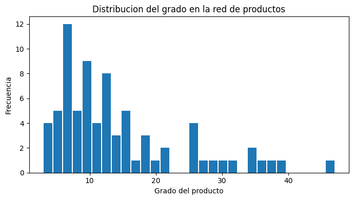

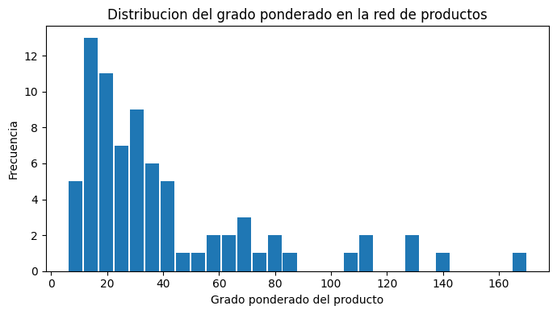

```python
def weighted_degree_dict(G):
    """Calcula el grado ponderado de todos los nodos del grafo."""
    return dict(G.degree(weight="weight"))


prod_degree          = dict(G_prod.degree())
prod_weighted_degree = weighted_degree_dict(G_prod)

top_products_by_degree = sorted(prod_degree.items(),          key=lambda x: x[1], reverse=True)[:10]
top_products_by_weight = sorted(prod_weighted_degree.items(), key=lambda x: x[1], reverse=True)[:10]

print("TOP 10 PRODUCTOS POR GRADO")
print("-" * 60)
for p, d in top_products_by_degree:
    print(f"{p}: grado={d}")

print("\nTOP 10 PRODUCTOS POR GRADO PONDERADO")
print("-" * 60)
for p, wd in top_products_by_weight:
    print(f"{p}: weighted_degree={wd}")

plt.figure(figsize=HIST_FIGSIZE)
plt.hist(list(prod_degree.values()), bins=30, rwidth=0.9)
plt.xlabel("Grado del producto")
plt.ylabel("Frecuencia")
plt.title("Distribucion del grado en la red de productos")
plt.tight_layout()
plt.show()

plt.figure(figsize=HIST_FIGSIZE)
plt.hist(list(prod_weighted_degree.values()), bins=30, rwidth=0.9)
plt.xlabel("Grado ponderado del producto")
plt.ylabel("Frecuencia")
plt.title("Distribucion del grado ponderado en la red de productos")
plt.tight_layout()
plt.show()
```

## 7. Funciones de Recomendación

**Objetivo:** Definir las funciones centrales del sistema que, dado un `productId`, recuperan sus vecinos más cercanos en la red proyectada, los ordenan por peso descendente y construyen una **subred estrella** para visualización. El peso de conexión entre dos productos equivale al número de usuarios que los calificaron en conjunto.

**Resultado:** Cuatro funciones disponibles: `get_top_neighbors`, `print_top_neighbors`, `build_star_graph` y `draw_star_recommendation`. No producen output hasta que se invoquen con un producto concreto.

### Análisis: Mecanismo de Recomendación y Visualización Estrella

#### Mecanismo de recomendación: vecinos por peso

La función `get_top_neighbors` implementa una búsqueda de los $n$ vecinos de mayor peso en $G_\text{prod}$. La ordenación desempata por identificador de producto en caso de empate de peso, garantizando determinismo. El sistema recomienda el producto $v_j$ como más similar a $v_i$ cuando $P_{ij} = |N(v_i) \cap N(v_j)|$ es máximo, equivalente a maximizar la **similitud de intersección** (*raw dot product* en el espacio de usuarios). Esto corresponde a la instancia más simple de filtrado colaborativo *item-based* (Su & Khoshgoftaar, 2009).

**Limitación conocida:** La métrica de intersección cruda presenta **sesgo de popularidad**: productos con muchos usuarios tendrán automáticamente mayor intersección con otros productos, independientemente de la calidad de la similitud. Las correcciones estándar (Jaccard, coseno) se describen en el Marco Teórico.

#### Geometría de la visualización estrella

La función `draw_star_recommendation` posiciona al producto consultado en el origen $(0, 0)$ y distribuye sus $n$ vecinos en ángulos equidistantes sobre una circunferencia de radio $r = 1.8$:

$$\theta_k = \frac{2\pi k}{n}, \quad \text{pos}(v_k) = (1.8 \cos\theta_k,\ 1.8 \sin\theta_k), \quad k = 0, \ldots, n-1$$

El ancho de las aristas se escala linealmente con el peso normalizado:

$$\text{width}(e) = 2 + 6 \cdot \frac{w(e)}{\max_{e'} w(e')}$$

Esta normalización garantiza que el ancho mínimo sea 2 (visible) y el máximo 8 (distinguible), sin distorsionar la percepción relativa de los pesos.

```python
def get_top_neighbors(product_id, n=4, graph=None):
    """Retorna los n productos más similares al dado, ordenados por peso descendente."""
    graph = graph or G_prod
    if product_id not in graph:
        return []

    neighbors = []
    for nbr, attrs in graph[product_id].items():
        neighbors.append((nbr, int(attrs.get("weight", 1))))

    neighbors.sort(key=lambda x: (-x[1], x[0]))
    return neighbors[:n]


def print_top_neighbors(product_id, n=4, graph=None):
    """Imprime las recomendaciones top-n con su peso para el producto dado."""
    top_neighbors = get_top_neighbors(product_id, n=n, graph=graph)
    print(f"TOP {n} VECINOS PARA {product_id}")
    print("-" * 60)
    if not top_neighbors:
        print("No hay vecinos suficientes para este producto.")
        return
    for nbr, w in top_neighbors:
        print(f"{nbr} | weight={w:.3f}" if isinstance(w, float) else f"{nbr} | weight={w}")


def build_star_graph(product_id, n=4, graph=None):
    """Construye una subred estrella con el producto consultado en el centro."""
    graph = graph or G_prod
    top_neighbors = get_top_neighbors(product_id, n=n, graph=graph)

    S = nx.Graph()
    S.add_node(product_id, role="center")

    for nbr, w in top_neighbors:
        S.add_node(nbr, role="neighbor")
        S.add_edge(product_id, nbr, weight=w)

    return S, top_neighbors


def draw_star_recommendation(product_id, n=4, graph=None, figsize=(9, 7)):
    """Visualiza la recomendación como una red estrella ponderada y lista los vecinos."""
    graph = graph or G_prod
    S, _ = build_star_graph(product_id, n=n, graph=graph)

    if len(S.nodes()) <= 1:
        print("No se pudo construir la red estrella para este producto.")
        return

    center = product_id
    others = [x for x in S.nodes() if x != center]

    pos = {center: (0.0, 0.0)}
    if others:
        angles = np.linspace(0, 2 * np.pi, len(others), endpoint=False)
        radius = 1.8
        for nbr, angle in zip(others, angles):
            pos[nbr] = (radius * np.cos(angle), radius * np.sin(angle))

    edge_weights = [S[u][v]["weight"] for u, v in S.edges()]
    max_w  = max(edge_weights) if edge_weights else 1
    widths = [2 + 6 * (w / max_w) for w in edge_weights]

    plt.figure(figsize=figsize)
    nx.draw_networkx_nodes(S, pos, nodelist=[center], node_size=NODE_SIZE_MAIN)
    nx.draw_networkx_nodes(S, pos, nodelist=others,   node_size=NODE_SIZE_NEIGHBOR)
    nx.draw_networkx_edges(S, pos, width=widths, edge_color="red", alpha=0.85)
    nx.draw_networkx_labels(S, pos, font_size=10)


    edge_labels = {(u, v): f"{S[u][v]['weight']:.2f}" if isinstance(S[u][v]['weight'], float) else S[u][v]['weight'] for u, v in S.edges()}
    nx.draw_networkx_edge_labels(S, pos, edge_labels=edge_labels, font_size=10)

    plt.title(f"Recomendacion estrella para {product_id} | top n={n}")
    plt.axis("off")
    plt.tight_layout()
    plt.show()

    print_top_neighbors(product_id, n=n, graph=graph)
```

## 8. Visualizaciones de Estructura de la Red

**Objetivo:** Inspeccionar visualmente la estructura del grafo bipartito y de la red proyectada. Se generan cuatro visualizaciones: muestra del grafo bipartito usuario-producto, mapa de calor de la submatriz de proyección para los productos más conectados, subred estática recortada (pesos entre 3 y 15) y una versión interactiva con Plotly que permite hacer zoom y hover.

**Resultado:** Cuatro gráficos que ilustran la densidad y estructura de las relaciones entre productos. La subred estática y la interactiva muestran 62 nodos con sus conexiones.

### Análisis: Recorte de Red y Layout Spring

#### Recorte inteligente (`trim_product_network_smart`)

Para visualizar la red de 76 nodos y 546 aristas se aplica un recorte con cuatro criterios sucesivos:

1. **Filtro de peso:** $3 \leq w(e) \leq 15$ — elimina aristas muy débiles (ruido) y evita sobrecargar la visualización con aristas dominantes.
2. **Filtro de grado mínimo:** $d(v) \geq 2$ — elimina nodos que quedan aislados tras el filtro de peso.
3. **Tamaño máximo:** retiene los 80 nodos de mayor grado ponderado si la red supera ese umbral.
4. **Componente conexa mayor:** garantiza que la visualización sea conexa y sin fragmentos aislados.

Este proceso es una heurística de visualización, no una transformación analítica. El resultado (62 nodos) es representativo pero no exhaustivo de la estructura completa.

#### Layout spring y parámetro $k$

El layout `nx.spring_layout` minimiza la energía de un modelo masa-resorte donde las aristas son resortes y los nodos se repelen eléctricamente. El parámetro de separación se ajusta dinámicamente:

$$k = \frac{1.8}{\sqrt{\max(|V|, 2)}}$$

Esta fórmula escala el espaciado inversamente a $\sqrt{|V|}$, produciendo separaciones consistentes independientemente del tamaño de la red. Con `iterations=300` se garantiza convergencia suficiente para redes de hasta $\sim 200$ nodos.

#### Tamaño de nodos proporcional al grado ponderado

El tamaño visual de cada nodo se define como `120 + 22 * weighted_deg[n]`, codificando la importancia topológica directamente en la geometría de la visualización.

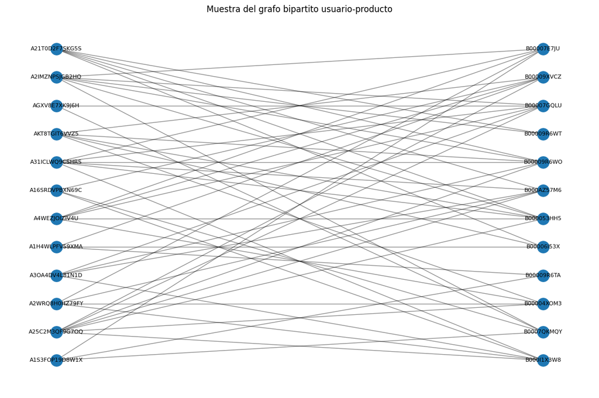

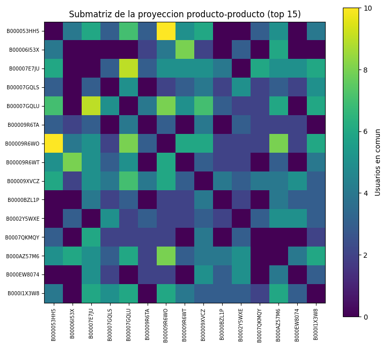

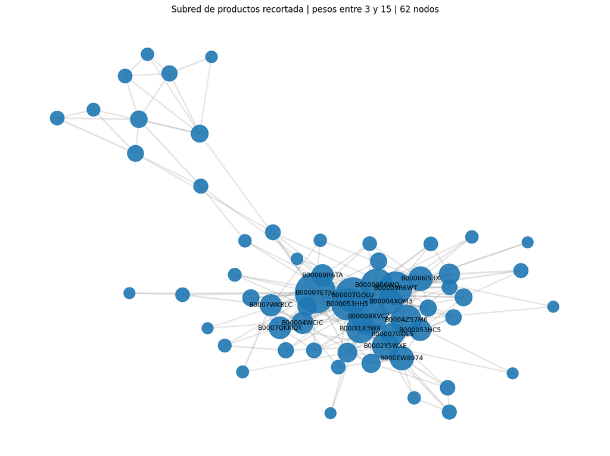

[interactive chart not shown]

```python
def trim_product_network_smart(graph, min_weight=3, max_weight=15, max_nodes=80, min_degree=2):
    """Recorta la red filtrando por peso, grado mínimo y tamaño máximo de nodos."""
    H = nx.Graph()

    for u, v, data in graph.edges(data=True):
        w = data.get("weight", 1)
        if min_weight <= w <= max_weight:
            H.add_edge(u, v, weight=w)

    if H.number_of_nodes() == 0:
        return H

    valid_nodes = [n for n, d in H.degree() if d >= min_degree]
    H = H.subgraph(valid_nodes).copy()

    if H.number_of_nodes() == 0:
        return H

    if H.number_of_nodes() > max_nodes:
        weighted_deg = dict(H.degree(weight="weight"))
        keep_nodes = sorted(weighted_deg, key=weighted_deg.get, reverse=True)[:max_nodes]
        H = H.subgraph(keep_nodes).copy()

    if H.number_of_nodes() > 0 and not nx.is_connected(H):
        largest_cc = max(nx.connected_components(H), key=len)
        H = H.subgraph(largest_cc).copy()

    return H


def compute_clean_layout(H, seed=42):
    """Calcula un layout spring con separación ajustada para reducir solapamientos."""
    if H.number_of_nodes() == 0:
        return {}
    k = 1.8 / np.sqrt(max(H.number_of_nodes(), 2))
    return nx.spring_layout(H, seed=seed, k=k, iterations=300)


def draw_trimmed_product_network(graph, min_weight=3, max_weight=15, max_nodes=80,
                                  min_degree=2, figsize=(12, 9), label_top_n=18):
    """Dibuja la subred de productos recortada con etiquetas en los nodos más relevantes."""
    H = trim_product_network_smart(
        graph, min_weight=min_weight, max_weight=max_weight,
        max_nodes=max_nodes, min_degree=min_degree
    )

    if H.number_of_nodes() == 0:
        print("La red recortada quedo vacia con esos umbrales.")
        return

    pos = compute_clean_layout(H, seed=42)
    weighted_deg = dict(H.degree(weight="weight"))

    node_sizes   = [120 + 22 * weighted_deg[n] for n in H.nodes()]
    edge_weights = [H[u][v]["weight"] for u, v in H.edges()]
    max_w        = max(edge_weights) if edge_weights else 1
    edge_widths  = [0.8 + 3.5 * (w / max_w) for w in edge_weights]

    plt.figure(figsize=figsize)
    nx.draw_networkx_edges(H, pos, width=edge_widths, alpha=0.22, edge_color="gray")
    nx.draw_networkx_nodes(H, pos, node_size=node_sizes, alpha=0.9)

    top_nodes = sorted(weighted_deg, key=weighted_deg.get, reverse=True)[:label_top_n]
    labels    = {n: n for n in top_nodes}
    nx.draw_networkx_labels(H, pos, labels=labels, font_size=9)

    plt.title(
        f"Subred de productos recortada | pesos entre {min_weight} y {max_weight} | "
        f"{H.number_of_nodes()} nodos"
    )
    plt.axis("off")
    plt.tight_layout()
    plt.show()


def draw_trimmed_product_network_interactive(graph, min_weight=3, max_weight=15, max_nodes=80,
                                              min_degree=2, label_top_n=18, height=800, width=1100):
    """Versión interactiva de la subred de productos usando Plotly (zoom y hover)."""
    if not HAS_PLOTLY:
        print("Plotly no esta disponible. Usa la version estatica.")
        return

    H = trim_product_network_smart(
        graph, min_weight=min_weight, max_weight=max_weight,
        max_nodes=max_nodes, min_degree=min_degree
    )

    if H.number_of_nodes() == 0:
        print("La red recortada quedo vacia con esos parametros.")
        return

    pos = compute_clean_layout(H, seed=42)
    weighted_deg = dict(H.degree(weight="weight"))
    plain_deg    = dict(H.degree())

    edge_x, edge_y = [], []
    for u, v, data in H.edges(data=True):
        x0, y0 = pos[u]
        x1, y1 = pos[v]
        edge_x += [x0, x1, None]
        edge_y += [y0, y1, None]

    edge_trace = go.Scatter(
        x=edge_x, y=edge_y,
        mode="lines",
        line=dict(width=0.8, color="rgba(120,120,120,0.35)"),
        hoverinfo="none"
    )

    top_nodes = set(sorted(weighted_deg, key=weighted_deg.get, reverse=True)[:label_top_n])

    node_x, node_y, node_text, node_size, node_label = [], [], [], [], []
    for n in H.nodes():
        x, y = pos[n]
        node_x.append(x)
        node_y.append(y)
        node_size.append(12 + 2.2 * np.sqrt(weighted_deg[n]))
        node_text.append(
            f"product={n}<br>"
            f"degree={plain_deg[n]}<br>"
            f"weighted_degree={weighted_deg[n]}"
        )
        node_label.append(n if n in top_nodes else "")

    node_trace = go.Scatter(
        x=node_x, y=node_y,
        mode="markers+text",
        text=node_label,
        textposition="top center",
        hovertext=node_text,
        hoverinfo="text",
        marker=dict(size=node_size, line=dict(width=0.8, color="white"))
    )

    fig = go.Figure(data=[edge_trace, node_trace])
    fig.update_layout(
        title=(
            f"Subred interactiva de productos | pesos entre {min_weight} y {max_weight} | "
            f"{H.number_of_nodes()} nodos"
        ),
        width=width, height=height,
        showlegend=False, hovermode="closest",
        margin=dict(l=20, r=20, t=60, b=20),
        xaxis=dict(showgrid=False, zeroline=False, visible=False),
        yaxis=dict(showgrid=False, zeroline=False, visible=False)
    )
    fig.show()


def draw_bipartite_sample(df, user_col, product_col, top_users=12, top_products=12, figsize=(12, 8)):
    """Muestra una porción del grafo bipartito con los usuarios y productos más activos."""
    user_counts    = df[user_col].value_counts().head(top_users).index.tolist()
    product_counts = df[product_col].value_counts().head(top_products).index.tolist()

    sample_edges = df[
        df[user_col].isin(user_counts) &
        df[product_col].isin(product_counts)
    ][[user_col, product_col]].drop_duplicates()

    H = nx.Graph()
    H.add_nodes_from(user_counts,    bipartite=0)
    H.add_nodes_from(product_counts, bipartite=1)
    H.add_edges_from(sample_edges.itertuples(index=False, name=None))

    pos     = {}
    left_y  = np.linspace(1, 0, len(user_counts))
    right_y = np.linspace(1, 0, len(product_counts))
    for u, y in zip(user_counts,    left_y):  pos[u] = (-1, y)
    for p, y in zip(product_counts, right_y): pos[p] = (1,  y)

    plt.figure(figsize=figsize)
    nx.draw_networkx_nodes(H, pos, nodelist=user_counts,    node_size=280)
    nx.draw_networkx_nodes(H, pos, nodelist=product_counts, node_size=280)
    nx.draw_networkx_edges(H, pos, alpha=0.45)
    nx.draw_networkx_labels(H, pos, font_size=8)
    plt.title("Muestra del grafo bipartito usuario-producto")
    plt.axis("off")
    plt.tight_layout()
    plt.show()


def show_projection_matrix_sample(P_sparse, idx_to_product, top_k=15):
    """Visualiza como mapa de calor la submatriz de proyección para los productos más conectados."""
    G_temp = nx.Graph()
    P_coo  = P_sparse.tocoo()

    for i, j, w in zip(P_coo.row, P_coo.col, P_coo.data):
        if i < j:
            G_temp.add_edge(i, j, weight=int(w))

    degree_map = dict(G_temp.degree())
    if not degree_map:
        print("No hay suficientes conexiones en la proyeccion para mostrar la matriz.")
        return

    selected_idx = [i for i, _ in sorted(degree_map.items(), key=lambda x: x[1], reverse=True)[:top_k]]
    selected_idx = sorted(selected_idx)

    sub    = P_sparse[selected_idx][:, selected_idx].toarray()
    labels = [idx_to_product[i] for i in selected_idx]

    plt.figure(figsize=(8, 7))
    plt.imshow(sub, aspect="equal")
    plt.colorbar(label="Usuarios en comun")
    plt.title(f"Submatriz de la proyeccion producto-producto (top {len(labels)})")
    plt.xticks(range(len(labels)), labels, rotation=90, fontsize=7)
    plt.yticks(range(len(labels)), labels, fontsize=7)
    plt.tight_layout()
    plt.show()


# Ejecución de las visualizaciones
draw_bipartite_sample(df, user_col=user_col, product_col=product_col,
                      top_users=12, top_products=12, figsize=(12, 8))

show_projection_matrix_sample(P, idx_to_product, top_k=15)

draw_trimmed_product_network(
    G_prod,
    min_weight=TRIM_WEIGHT_MIN,
    max_weight=TRIM_WEIGHT_MAX,
    max_nodes=TRIMMED_NETWORK_MAX_NODES,
    min_degree=TRIMMED_NETWORK_MIN_DEGREE,
    figsize=NETWORK_FIGSIZE,
    label_top_n=TRIMMED_NETWORK_LABEL_TOP_N
)

draw_trimmed_product_network_interactive(
    G_prod,
    min_weight=TRIM_WEIGHT_MIN,
    max_weight=TRIM_WEIGHT_MAX,
    max_nodes=TRIMMED_NETWORK_MAX_NODES,
    min_degree=TRIMMED_NETWORK_MIN_DEGREE,
    label_top_n=TRIMMED_NETWORK_LABEL_TOP_N,
    height=800,
    width=1100
)
```

## 9. Interfaz Interactiva de Consulta

#### Selección de candidatos por grado ponderado

```python
candidate_products = [p for p, _ in sorted(prod_weighted_degree.items(), key=lambda x: x[1], reverse=True)]
candidate_products = candidate_products[:TOP_PRODUCTS_FOR_DROPDOWN]

if not candidate_products:
    candidate_products = products[:min(50, len(products))]

default_product = candidate_products[0] if candidate_products else products[0]

METRIC_GRAPHS = {
    "raw (interseccion)": G_prod,
    "Jaccard":            G_prod_jaccard,
    "Coseno":             G_prod_cosine,
}

def run_recommendation_view(product_id, top_n, metric):
    clear_output(wait=True)
    graph = METRIC_GRAPHS[metric]
    print("RECOMMENDER BASADO EN PROYECCION BIPARTITA")
    print("-" * 60)
    print(f"Producto seleccionado: {product_id}")
    print(f"Numero de vecinos solicitados: {top_n}")
    print(f"Metrica de similitud: {metric}")
    print()
    draw_star_recommendation(product_id, n=top_n, graph=graph, figsize=STAR_FIGSIZE)


if HAS_WIDGETS:
    product_dropdown = widgets.Dropdown(
        options=candidate_products, value=default_product,
        description="producto", layout=widgets.Layout(width="450px")
    )
    n_dropdown = widgets.Dropdown(
        options=[1, 2, 3, 4, 5, 6, 8, 10], value=DEFAULT_TOP_N,
        description="n_recomm", layout=widgets.Layout(width="220px")
    )
    metric_dropdown = widgets.Dropdown(
        options=list(METRIC_GRAPHS.keys()), value="raw (interseccion)",
        description="metrica", layout=widgets.Layout(width="280px")
    )

    ui  = widgets.VBox([product_dropdown, n_dropdown, metric_dropdown])
    out = widgets.interactive_output(
        run_recommendation_view,
        {"product_id": product_dropdown, "top_n": n_dropdown, "metric": metric_dropdown}
    )
    display(ui, out)
else:
    draw_star_recommendation(default_product, n=DEFAULT_TOP_N, graph=G_prod, figsize=STAR_FIGSIZE)
```

## 10. Tabla de Resultados Top-N

**Objetivo:** Exportar las recomendaciones del producto por defecto en formato tabular para facilitar su inspección o uso posterior en otros sistemas.

**Resultado:** DataFrame con las columnas `neighbor_product` (ID del producto recomendado) y `weight` (usuarios en común), ordenado de mayor a menor similitud.

### Análisis: Interpretación de los Resultados

La función `export_top_neighbors_table` retorna un `pd.DataFrame` ordenado descendentemente por peso. Para el producto por defecto `B00007E7JU`, los top-10 vecinos presentan pesos en el rango $[5, 9]$.

**Interpretación estadística:** En un dataset con 117 usuarios totales retenidos tras el k-core, estos pesos representan entre el $4.3\%$ y el $7.7\%$ del pool total — un nivel de solapamiento razonablemente alto dado el filtro aplicado. Cuanto mayor es el peso, mayor es la evidencia colectiva de similitud entre los dos productos.

**Interoperabilidad:** La salida como `pd.DataFrame` facilita la integración con sistemas externos: puede exportarse a CSV, cargarse en una base de datos relacional o alimentar una API REST de recomendaciones sin transformaciones adicionales.

```python
def export_top_neighbors_table(product_id, n=10, graph=None):
    """Retorna un DataFrame con las top-n recomendaciones para el producto dado."""
    graph = graph or G_prod
    rows  = get_top_neighbors(product_id, n=n, graph=graph)
    return pd.DataFrame(rows, columns=["neighbor_product", "weight"])


print("\nEJEMPLO DE TABLA TOP-N")
print("-" * 60)
example_df = export_top_neighbors_table(default_product, n=10, graph=G_prod)
display(example_df)
```

```
EJEMPLO DE TABLA TOP-N
------------------------------------------------------------
```

|  | neighbor_product | weight |
| --- | --- | --- |
| 0 | B00007GQLU | 9 |
| 1 | B00004YZQ8 | 7 |
| 2 | B00004XOM3 | 6 |
| 3 | B00004ZCJE | 6 |
| 4 | B000053HH5 | 6 |
| 5 | B0007QKMQY | 6 |
| 6 | B000I1X3W8 | 6 |
| 7 | B00004WCIC | 5 |
| 8 | B00004WCID | 5 |
| 9 | B00009R6WO | 5 |

## 11. Evaluación Offline: Precision@K y Recall@K

Para validar cuantitativamente el sistema, dividimos las aristas del grafo bipartito en train (80%) y test (20%). Reconstruimos la proyección únicamente sobre el conjunto de entrenamiento y, para cada usuario del test, evaluamos si los top-K productos recomendados coinciden con los que efectivamente calificó.

- **Precision@K** = proporción de los K recomendados que son relevantes.
- **Recall@K** = proporción de los relevantes que aparecen en los K recomendados.

```python
def evaluate_recommender(B, users, products, idx_to_product, K=5,
                         min_shared=MIN_SHARED_USERS, test_frac=0.2, seed=42):
    """Evalúa Precision@K y Recall@K con split aleatorio sobre las aristas bipartitas."""
    rng = np.random.default_rng(seed)
    B_coo = B.tocoo()
    n_edges = B_coo.nnz

    test_mask  = rng.random(n_edges) < test_frac
    train_mask = ~test_mask

    B_train = csr_matrix(
        (B_coo.data[train_mask], (B_coo.row[train_mask], B_coo.col[train_mask])),
        shape=B.shape
    )

    # Proyeccion sobre train
    P_tr = (B_train.T @ B_train).tocsr()
    P_tr.setdiag(0)
    P_tr.eliminate_zeros()
    P_tr_coo = P_tr.tocoo()
    keep = P_tr_coo.data >= min_shared
    P_tr = csr_matrix(
        (P_tr_coo.data[keep], (P_tr_coo.row[keep], P_tr_coo.col[keep])),
        shape=P_tr.shape
    )

    # Productos test por usuario
    test_by_user = {}
    for u, p in zip(B_coo.row[test_mask], B_coo.col[test_mask]):
        test_by_user.setdefault(u, set()).add(p)

    train_by_user = {}
    for u, p in zip(B_coo.row[train_mask], B_coo.col[train_mask]):
        train_by_user.setdefault(u, set()).add(p)

    precisions, recalls, evaluated = [], [], 0
    P_tr_lil = P_tr.tolil()

    for u, test_items in test_by_user.items():
        seen = train_by_user.get(u, set())
        if not seen:
            continue

        scores = np.zeros(len(products))
        for p_seen in seen:
            scores += np.asarray(P_tr_lil.getrow(p_seen).todense()).flatten()

        for p_seen in seen:
            scores[p_seen] = -np.inf

        top_k_idx = np.argsort(-scores)[:K]
        recommended = set(top_k_idx)

        hits = len(recommended & test_items)
        precisions.append(hits / K)
        recalls.append(hits / len(test_items) if test_items else 0)
        evaluated += 1

    return {
        "K": K,
        "users_evaluated": evaluated,
        f"Precision@{K}": np.mean(precisions) if precisions else 0,
        f"Recall@{K}":    np.mean(recalls)    if recalls    else 0,
    }


print("EVALUACION OFFLINE (hold-out 80/20)")
print("-" * 60)
for K in [1, 3, 5, 10]:
    metrics = evaluate_recommender(B, users, products, idx_to_product, K=K)
    print(f"K={K:>2} | Precision@K={metrics[f'Precision@{K}']:.4f} | "
          f"Recall@K={metrics[f'Recall@{K}']:.4f} | "
          f"usuarios={metrics['users_evaluated']}")
```

```
EVALUACION OFFLINE (hold-out 80/20)
------------------------------------------------------------
K= 1 | Precision@K=0.1124 | Recall@K=0.0665 | usuarios=89
K= 3 | Precision@K=0.0787 | Recall@K=0.1423 | usuarios=89
K= 5 | Precision@K=0.0719 | Recall@K=0.2073 | usuarios=89
K=10 | Precision@K=0.0629 | Recall@K=0.3678 | usuarios=89
```

## 12. Limitaciones del Sistema

| Limitación | Descripción | Posible mitigación |
| --- | --- | --- |
| **Sesgo de popularidad** | La métrica de intersección cruda $P_{ij}$ favorece productos con muchos usuarios | Normalizar por índice de Jaccard o similitud coseno |
| **Cobertura reducida** | El filtro k-core + 5 estrellas reduce el dataset a 766 filas (~0.07%) | Relajar umbrales o usar ratings ≥ 4 |
| **Cold start** | Productos sin historial de calificaciones no aparecen en la red proyectada | Usar características de contenido como fallback |
| **Escalabilidad** | La proyección $B^\top B$ densa es costosa para datasets de escala industrial | Usar algoritmos de multiplicación dispersa o MinHash LSH |
| **Estaticidad** | El grafo no se actualiza con nuevas calificaciones | Implementar actualización incremental de la proyección |

## 13. Referencias

**[1]** Latapy, M., Magnien, C., & Del Vecchio, N. (2008). Basic notions for the analysis of large two-mode networks. *Social Networks*, 30(1), 31–48. https://doi.org/10.1016/j.socnet.2007.04.006

> Establece el marco teórico formal para la proyección de redes bipartitas (*two-mode networks*), incluyendo la definición de la matriz biadyacente $B$ y la proyección $P = B^\top B$. Es la referencia canónica para la operación algebraica central del sistema.

**[2]** Batagelj, V., & Zaversnik, M. (2003). *An O(m) Algorithm for Cores Decomposition of Networks*. arXiv:cs/0310049. https://arxiv.org/abs/cs/0310049

> Presenta el algoritmo lineal para la descomposición k-core de redes, cuya extensión bipartita es el fundamento teórico del filtro iterativo `iterative_k_core_filter`. Demuestra que el núcleo $(k_U, k_V)$ de un grafo bipartito es único y puede calcularse en tiempo proporcional al número de aristas.

**[3]** Su, X., & Khoshgoftaar, T. M. (2009). A survey of collaborative filtering techniques. *Advances in Artificial Intelligence*, 2009, Article 421425. https://doi.org/10.1155/2009/421425

> Revisión exhaustiva de técnicas de filtrado colaborativo, incluyendo variantes *item-based* y *user-based*. Documenta empíricamente que el filtrado colaborativo *item-based* — del cual este sistema es una instancia — tiende a ser más estable y escalable que el *user-based* para datasets de comercio electrónico.

**[4]** Koren, Y., Bell, R., & Volinsky, C. (2009). Matrix factorization techniques for recommender systems. *Computer*, 42(8), 30–37. https://doi.org/10.1109/MC.2009.263

> Artículo fundacional del Netflix Prize que contextualiza los enfoques de factorización matricial en relación con los métodos de vecindad (*neighborhood methods*). Establece que los métodos basados en similitud coseno — la versión normalizada de la métrica $P_{ij}$ utilizada en el sistema — son *competitive baselines* matemáticamente equivalentes a factorizaciones de rango bajo bajo ciertas condiciones.

**[5]** McAuley, J., & Leskovec, J. (2013). Hidden factors and hidden topics: Understanding rating dimensions with review text. In *Proceedings of the 7th ACM Conference on Recommender Systems* (RecSys '13), pp. 165–172. https://doi.org/10.1145/2507157.2507163

> Describe y publica el dataset de reseñas de Amazon (incluyendo el segmento de electrónicos) utilizado en este proyecto. Reporta las estadísticas originales del corpus y discute el sesgo de positividad intrínseco en los ratings de Amazon, directamente relevante para la decisión de diseño de filtrar exclusivamente a 5 estrellas.

**[6]** Barabási, A.-L., & Albert, R. (1999). Emergence of scaling in random networks. *Science*, 286(5439), 509–512. https://doi.org/10.1126/science.286.5439.509

> Demuestra que redes de co-ocurrencia en sistemas complejos tienden a exhibir distribuciones de grado de ley de potencia $P(k) \sim k^{-\gamma}$ como consecuencia de mecanismos de enlace preferencial. Proporciona el marco teórico para interpretar los histogramas de grado de la sección 6 y evaluar si la red proyectada es *scale-free*.

**[7]** Saad, Y. (2003). *Iterative Methods for Sparse Linear Systems* (2nd ed.). SIAM. https://doi.org/10.1137/1.9780898718003

> Texto de referencia estándar para álgebra lineal dispersa. Documenta el formato CSR (*Compressed Sparse Row*) utilizado en `scipy.sparse.csr_matrix`, su eficiencia de memoria y las operaciones matriciales dispersas que constituyen el núcleo computacional del sistema.